# Project Study - Data Presemtation

# Visualization

## Trust in EU and UN over Time for all three Countries

### Option 1

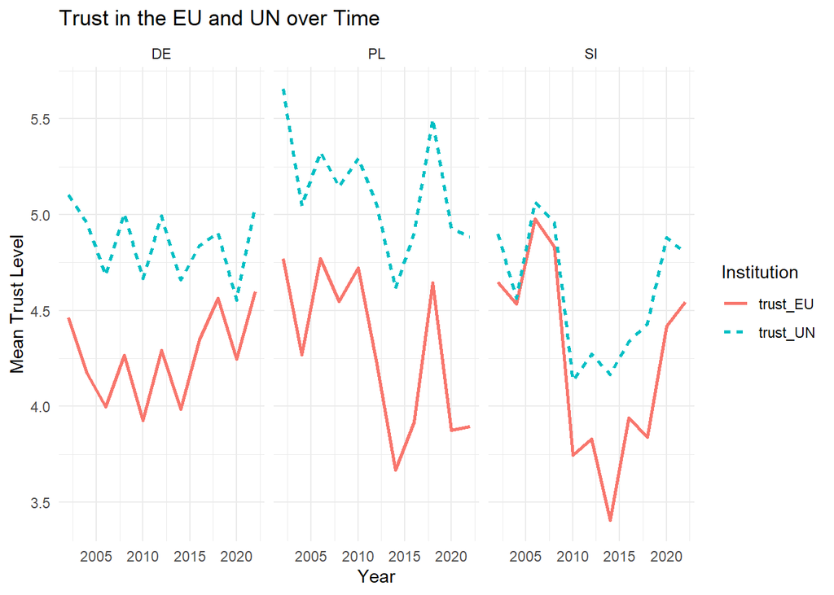

```r
# Creating a summary dataset "trust_trends" -> Summarize mean trust per country and round and assign year
trust_trends <- dt_new %>%
  filter(cntry %in% c("DE", "PL", "SI")) %>%
  group_by(cntry, essround) %>%
  summarise(
    trust_EU = mean(trstep, na.rm = TRUE),
    trust_UN = mean(trstun, na.rm = TRUE),
    .groups = "drop"
  ) %>%
  mutate(year = case_when(    # Mapping ESS round to the year they were conducted in in "year"
    essround == 1 ~ 2002,
    essround == 2 ~ 2004,
    essround == 3 ~ 2006,
    essround == 4 ~ 2008,
    essround == 5 ~ 2010,
    essround == 6 ~ 2012,
    essround == 7 ~ 2014,
    essround == 8 ~ 2016,
    essround == 9 ~ 2018,
    essround == 10 ~ 2020,
    essround == 11 ~ 2022,
    TRUE ~ NA_real_
  ))

#Reshaping to long format for plotting
trust_long <- trust_trends %>%
  pivot_longer(cols = c(trust_EU, trust_UN),
               names_to = "institution",
               values_to = "trust")

#Plotting the time trend
ggplot(trust_long, aes(x = year, y = trust, color = institution, linetype = institution)) +
  geom_line(size = 1) +
  facet_wrap(~cntry) +
  labs(
    title = "Trust in the EU and UN over Time",
    x = "Year",
    y = "Mean Trust Level",
    color = "Institution",
    linetype = "Institution"
  ) +
  theme_minimal()
```

- Trust in EU is lower than trust in UN across all countries.
- Mean trust in UN is the highest in Poland.
- Slovenia shows the highest fluctuations in mean trust in the EU, with a sharp decline between 2006 and 2014.

### Option 2

**Plot 1 – Trust in EU over Time**

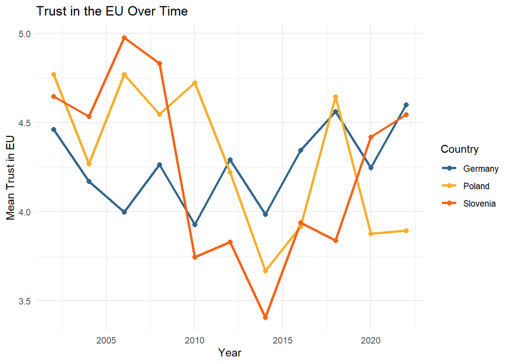

```r
ggplot(trust_trends, aes(x = year, y = trust_EU, color = cntry)) +
  geom_line(size = 1.2) +
  geom_point(size = 2) +
  scale_color_manual(
    values = c(
      "DE" = "#33658a",  # Germany
      "PL" = "#f6ae2d",  # Poland
      "SI" = "#f26419"   # Slovenia
    ),
    labels = c("DE" = "Germany", "PL" = "Poland", "SI" = "Slovenia")
  ) +
  labs(
    title = "Trust in the EU Over Time",
    x = "Year",
    y = "Mean Trust in EU",
    color = "Country"
  ) +
  theme_minimal()
```

### Plot 2 – Trust in UN over Time

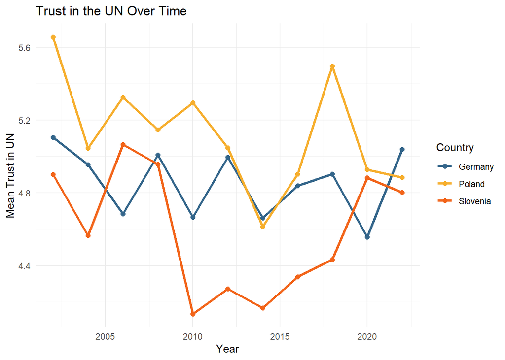

```r
ggplot(trust_trends, aes(x = year, y = trust_UN, color = cntry)) +
  geom_line(size = 1.2) +
  geom_point(size = 2) +
  scale_color_manual(
    values = c(
      "DE" = "#33658a",  # Germany
      "PL" = "#f6ae2d",  # Poland
      "SI" = "#f26419"   # Slovenia
    ),
    labels = c("DE" = "Germany", "PL" = "Poland", "SI" = "Slovenia")
  ) +
  labs(
    title = "Trust in the UN Over Time",
    x = "Year",
    y = "Mean Trust in UN",
    color = "Country"
  ) +
  theme_minimal()
```

## Distribution of Age Groups

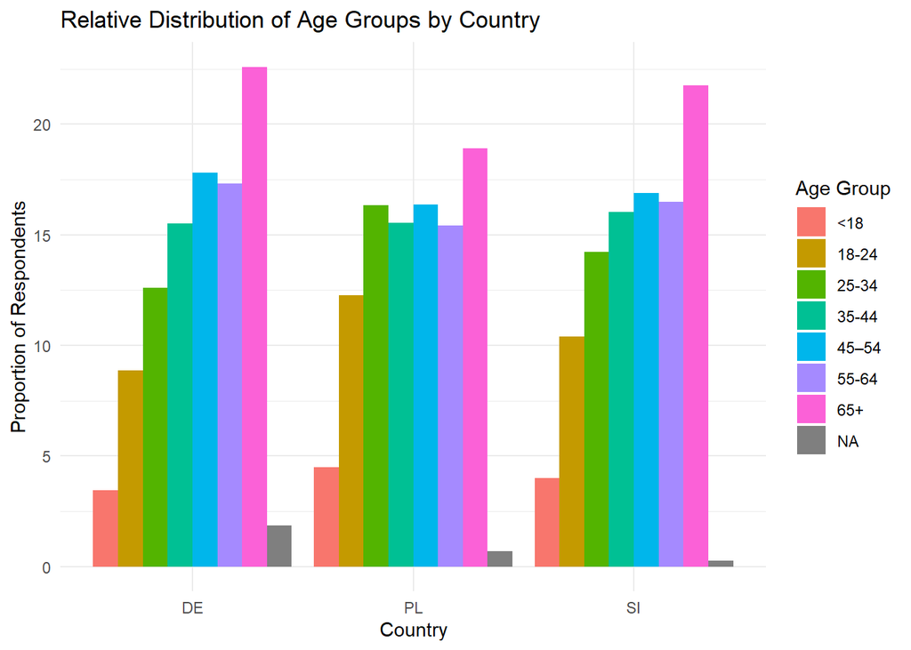

```r
dt_new %>%
  count(cntry, age_group) %>%
  group_by(cntry) %>%
  mutate(prop = n / sum(n) * 100) %>%
  ggplot(aes(x = cntry, y = prop, fill = age_group)) +
  geom_col(position = "dodge") +
  labs(
    title = "Relative Distribution of Age Groups by Country",
    x = "Country",
    y = "Proportion of Respondents",
    fill = "Age Group"
  ) +
  theme_minimal()
```

- Among all countries, the age group “65+” has the highest share.
- Age distribution has an upward trend in all three countries, indicating an aging population.

## Average Trust in EU by Age Group and Country

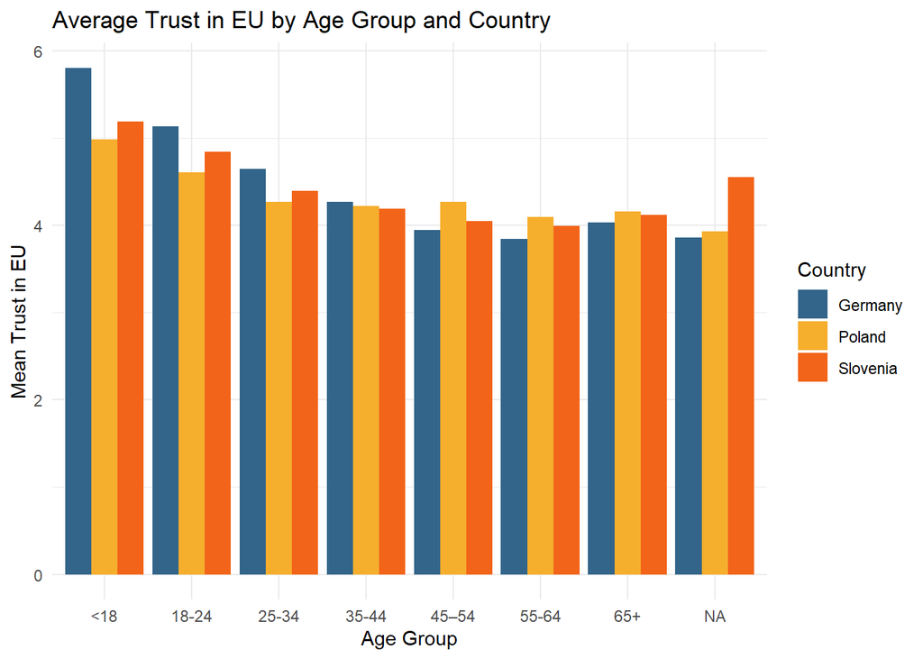

```r
dt_new %>%
  group_by(cntry, age_group) %>%
  summarise(mean_trustEU = mean(trstep, na.rm = TRUE), .groups = "drop") %>%
  ggplot(aes(x = age_group, y = mean_trustEU, fill = cntry)) +
  geom_col(position = "dodge") +
  scale_fill_manual(
    values = c(
      "DE" = "#33658a",     # Germany - Blue
      "PL" = "#f6ae2d",     # Poland - Light Orange
      "SI" = "#f26419"      # Slovenia - Dark Orange/Pink
    ),
    labels = c(
      "DE" = "Germany",
      "PL" = "Poland",
      "SI" = "Slovenia"
    )
  ) +
  labs(
    title = "Average Trust in EU by Age Group and Country",
    x = "Age Group",
    y = "Mean Trust in EU",
    fill = "Country"
  ) +
  theme_minimal()
```

- Highest mean trust in EU among people younger than 18 in all three countries, with respondents from Germany having the highest trust.
- General downward trend in meant trust in EU across all countries up to the age group 55-64.
- Trust increases again for respondents being 65 or older.

## Average Trust in UN by Age Group and Country

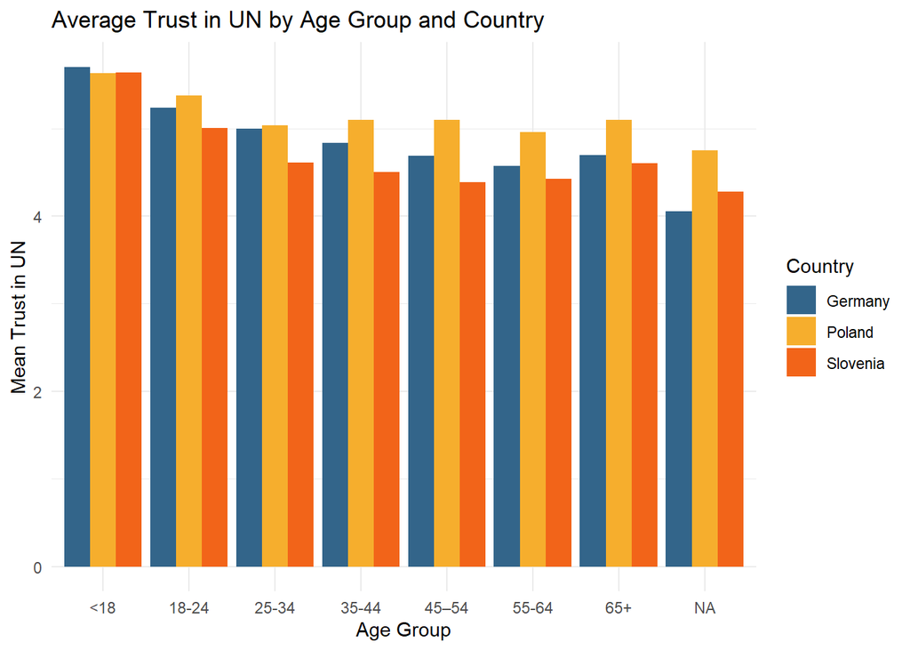

```r
dt_new %>%
  group_by(cntry, age_group) %>%
  summarise(mean_trustUN = mean(trstun, na.rm = TRUE), .groups = "drop") %>%
  ggplot(aes(x = age_group, y = mean_trustUN, fill = cntry)) +
  geom_col(position = "dodge") +
  scale_fill_manual(
    values = c(
      "DE" = "#33658a",     # Germany - Blue
      "PL" = "#f6ae2d",     # Poland - Light Orange
      "SI" = "#f26419"      # Slovenia - Dark Orange/Pink
    ),
    labels = c(
      "DE" = "Germany",
      "PL" = "Poland",
      "SI" = "Slovenia"
    )
  ) +
  labs(
    title = "Average Trust in UN by Age Group and Country",
    x = "Age Group",
    y = "Mean Trust in UN",
    fill = "Country"
  ) +
  theme_minimal()
```

- Highest mean trust in UN among people younger than 18 in all three countries, with respondents from Germany having the highest trust.
- General downward trend in meant trust in EU in Germany and Slovenia up to the age group 55-64.
- Different pattern for Poland: trust decreases until the age group 25-34 and increases again, staying stable for the remaining age groups and being higher than the respective age groups in Germany and Slovenia.
- Trust increases again for respondents being 65 or older.

[figure not shown]

```r
dt_new %>%
  group_by(cntry, age_group) %>%
  summarise(mean_trustpol = mean(polintr_rev, na.rm = TRUE), .groups = "drop") %>%
  ggplot(aes(x = age_group, y = mean_trustpol, fill = cntry)) +
  geom_col(position = "dodge") +
  scale_fill_manual(
    values = c(
      "DE" = "#33658a",     # Germany - Blue
      "PL" = "#f6ae2d",     # Poland - Light Orange
      "SI" = "#f26419"      # Slovenia - Dark Orange/Pink
    ),
    labels = c(
      "DE" = "Germany",
      "PL" = "Poland",
      "SI" = "Slovenia"
    )
  ) +
  labs(
    title = "Average Trust in Politicians by Age Group and Country",
    x = "Age Group",
    y = "Mean Trust in Politicians",
    fill = "Country"
  ) +
  theme_minimal()
```

## Left-Right Political Placement across Countries

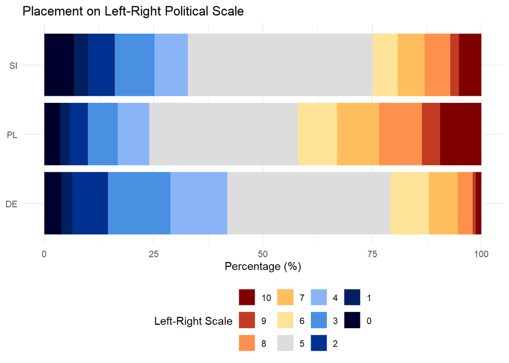

```r
# Filtering to valid left-right scale values
lr_data <- dt_new %>%
  filter(!is.na(lrscale)) %>%
  group_by(cntry, lrscale) %>%
  summarise(count = n(), .groups = "drop") %>%
  group_by(cntry) %>%
  mutate(percentage = count / sum(count) * 100)


#Plotting the diverging stacked bar chart
ggplot(lr_data, aes(x = cntry, y = percentage, fill = factor(lrscale, levels = rev(0:10)))) +
  geom_bar(stat = "identity", position = "stack") +
  coord_flip() +
  scale_fill_manual(
    values = c(
      "0" = "#00002E", "1" = "#002060", "2" = "#003090", "3" = "#4A90E2",
      "4" = "#8AB4F8", "5" = "#DDDDDD",
      "6" = "#FFE399", "7" = "#FFBE5C", "8" = "#FF914D", "9" = "#C23B22", "10" = "#800000"
    ),
    name = "Left-Right Scale"
  ) +
  labs(
    title = "Placement on Left-Right Political Scale",
    x = NULL,
    y = "Percentage (%)"
  ) +
  theme_minimal() +
  theme(legend.position = "bottom")
```

- Highest share of respondents selected 5 as their political attitude.
- Higher share of respondents in Germany and Slovenia are rather left.
- Higher share of respondents in Poland are rather right.

## Satisfaction with Democracy by Country

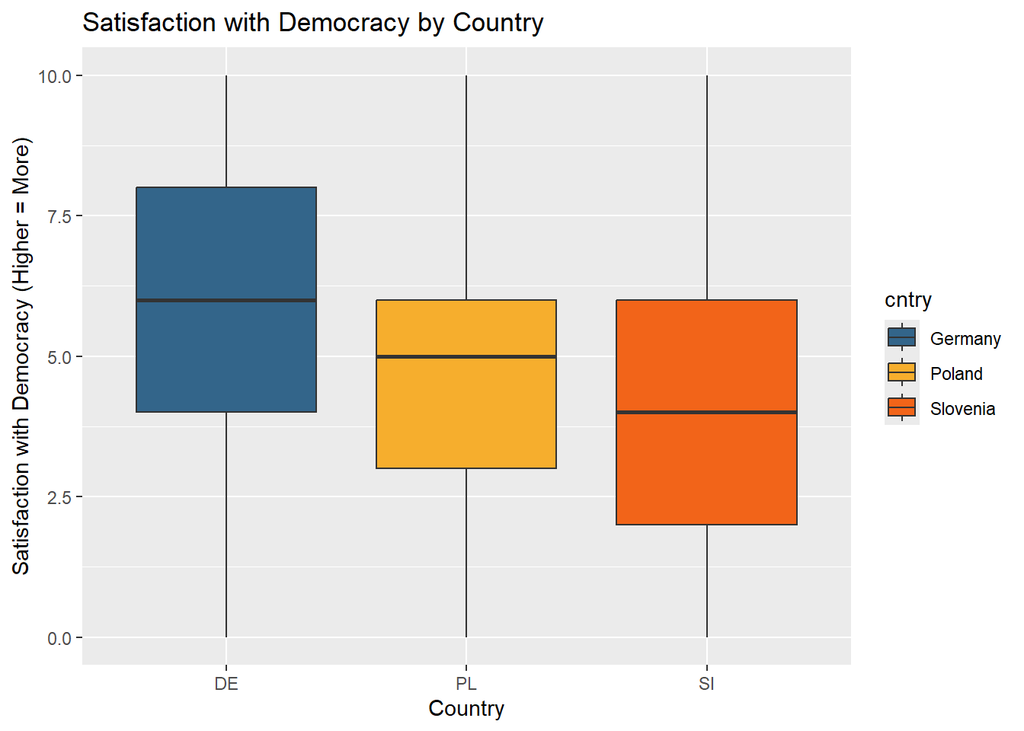

```r
ggplot(dt_new, aes(x = cntry, y = stfdem, fill = cntry)) +
  geom_boxplot() +
    scale_fill_manual(
    values = c(
      "DE" = "#33658a",   # Germany - Blue
      "PL" = "#f6ae2d",   # Poland - Light Orange
      "SI" = "#f26419"    # Slovenia - Dark Orange/Pink
    ),
    labels = c("DE" = "Germany", "PL" = "Poland", "SI" = "Slovenia")
  ) +
  labs(title = "Satisfaction with Democracy by Country ",
       y = "Satisfaction with Democracy (Higher = More)", x = "Country")
```

- Satisfaction with democracy highest in Germany and lowest in Slovenia.

## Satisfaction with Government by Country

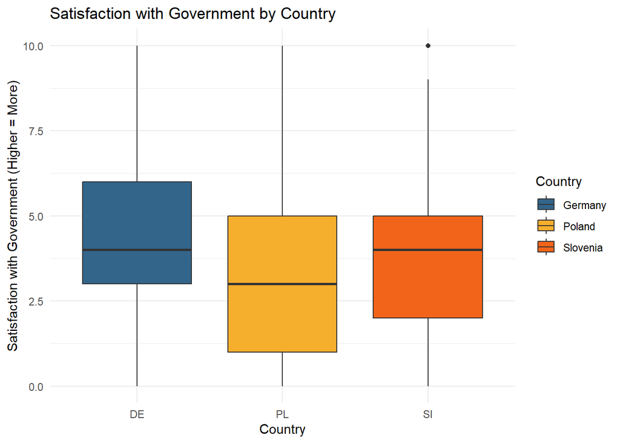

```r
ggplot(dt_new, aes(x = cntry, y = stfgov, fill = cntry)) +
  geom_boxplot() +
  scale_fill_manual(
    values = c(
      "DE" = "#33658a",   # Germany - Blue
      "PL" = "#f6ae2d",   # Poland - Light Orange
      "SI" = "#f26419"    # Slovenia - Dark Orange/Pink
    ),
    labels = c("DE" = "Germany", "PL" = "Poland", "SI" = "Slovenia")
  ) +
  labs(
    title = "Satisfaction with Government by Country",
    y = "Satisfaction with Government (Higher = More)",
    x = "Country",
    fill = "Country"
  ) +
  theme_minimal()
```

## Education Years per Country

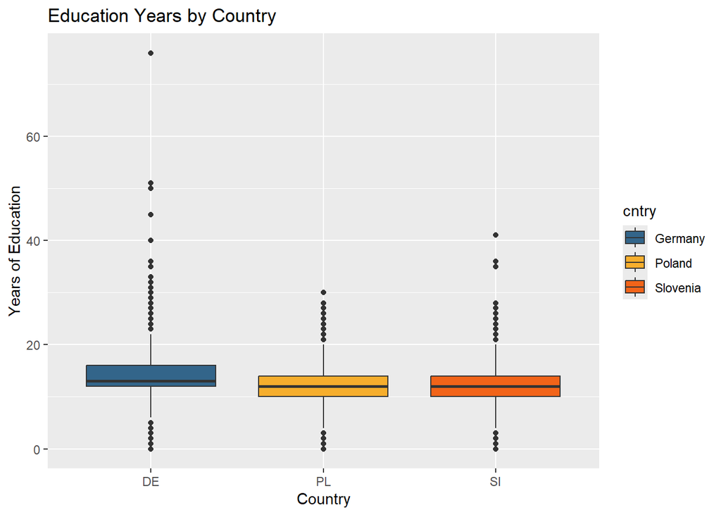

```r
ggplot(dt_new, aes(x = cntry, y = eduyrs, fill = cntry)) +
  geom_boxplot() +
  scale_fill_manual(
    values = c(
      "DE" = "#33658a",   # Germany - Blue
      "PL" = "#f6ae2d",   # Poland - Light Orange
      "SI" = "#f26419"    # Slovenia - Dark Orange/Pink
    ),
    labels = c("DE" = "Germany", "PL" = "Poland", "SI" = "Slovenia")
  ) +
  labs(title = "Education Years by Country",
       y = "Years of Education", x = "Country")
```

- Very high outliers for all three countries, especially for Germany. –> maybe check them and delete them?

## Years of Education by Age Group and Country

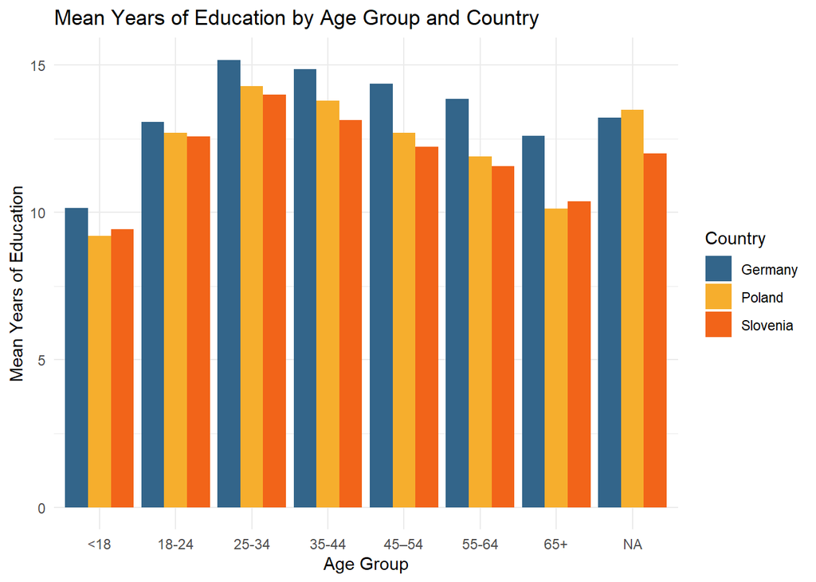

```r
dt_new %>%
  group_by(age_group, cntry) %>%
  summarise(mean_eduyrs = mean(eduyrs, na.rm = TRUE), .groups = "drop") %>%
  ggplot(aes(x = age_group, y = mean_eduyrs, fill = cntry)) +
  geom_col(position = "dodge") +
  scale_fill_manual(
    values = c(
      "DE" = "#33658a",   # Germany
      "PL" = "#f6ae2d",   # Poland
      "SI" = "#f26419"    # Slovenia
    ),
    labels = c("DE" = "Germany", "PL" = "Poland", "SI" = "Slovenia")
  ) +
  labs(
    title = "Mean Years of Education by Age Group and Country",
    x = "Age Group",
    y = "Mean Years of Education",
    fill = "Country"
  ) +
  theme_minimal()
```

- Graph illustrates differences among age groups across countries.
- Germany has the highest average years of education among all age groups, but important to keep outliers in mind.

## Attitudes towards Immigrants by Age Group and Country

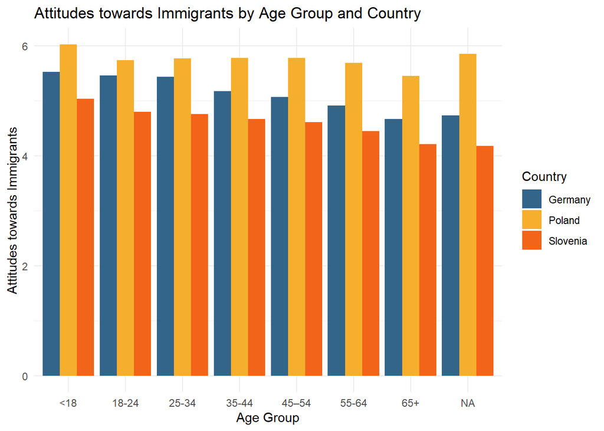

```r
dt_new %>%
  group_by(age_group, cntry) %>%
  summarise(mean_imwbcnt = mean(imwbcnt, na.rm = TRUE), .groups = "drop") %>%
  ggplot(aes(x = age_group, y = mean_imwbcnt, fill = cntry)) +
  geom_col(position = "dodge") +
  scale_fill_manual(
    values = c(
      "DE" = "#33658a",   # Germany
      "PL" = "#f6ae2d",   # Poland
      "SI" = "#f26419"    # Slovenia
    ),
    labels = c("DE" = "Germany", "PL" = "Poland", "SI" = "Slovenia")
  ) +
  labs(
    title = "Attitudes towards Immigrants by Age Group and Country",
    x = "Age Group",
    y = "Attitudes towards Immigrants",
    fill = "Country"
  ) +
  theme_minimal()
```

- Polish respondents seem to be more welcoming of immigrants among all age groups.
- Slovenian respondents seem to be the least welcoming of immigrants among all age groups.
- This seems to be a contradiction to the distribution of the left-right scale, where a higher share of Polish respondents indicated to be more right, and a higher share of Slovenian respondents indicated to be more left.
- A boxplot in the next step could help to check for outliers.
- Reasons??

## Immigration Attitude per Country

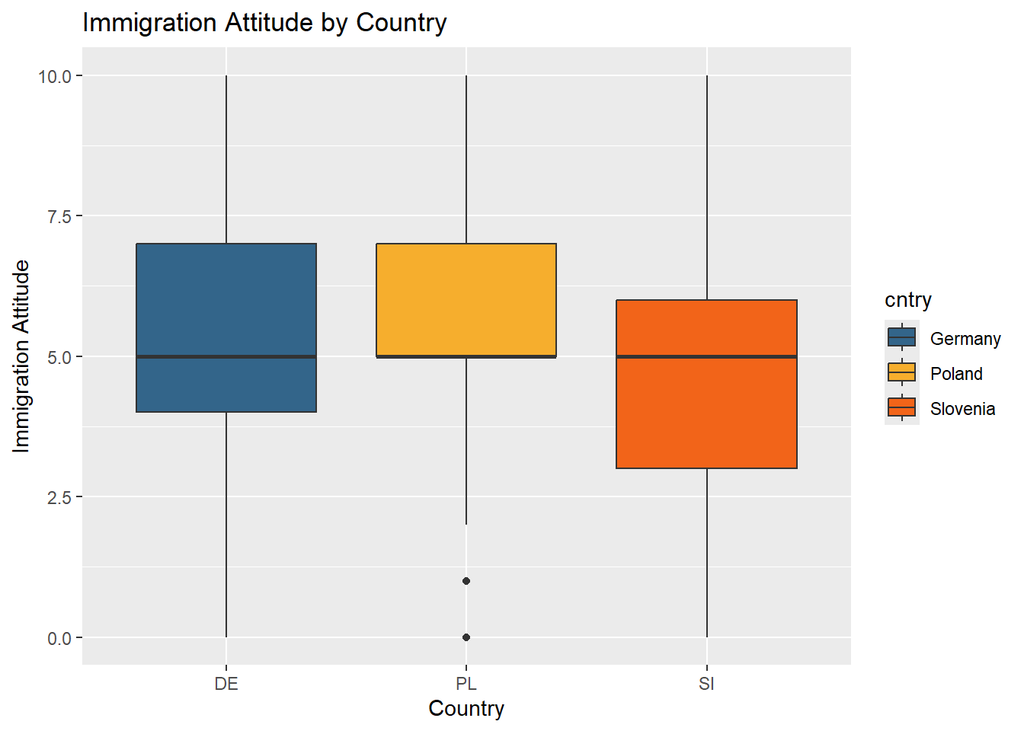

```r
ggplot(dt_new, aes(x = cntry, y = imwbcnt, fill = cntry)) +
  geom_boxplot() +
  scale_fill_manual(
    values = c(
      "DE" = "#33658a",   # Germany - Blue
      "PL" = "#f6ae2d",   # Poland - Light Orange
      "SI" = "#f26419"    # Slovenia - Dark Orange/Pink
    ),
    labels = c("DE" = "Germany", "PL" = "Poland", "SI" = "Slovenia")
  ) +
  labs(title = "Immigration Attitude by Country",
       y = "Immigration Attitude", x = "Country")
```

- There do not seem to be high outliers for immigration attitude among Polish respondents.
- Why are Polish respondents so welcoming when they are rather right? Would be interesting to see if the respondents who are rather right are also more welcoming, or if the average is high because of the very high immigration attitude among rather left respondents.

# Models

## Correlation Matrices

**Germany**

```r
dt_new %>%
  filter(cntry == "DE") %>%
  select(trstun, trstep, polintr_rev, eduyrs, agea, lrscale, stfdem, stfgov, imwbcnt, trstplt) %>%
  cor(use = "pairwise.complete.obs")
```

```
##                  trstun      trstep polintr_rev      eduyrs         agea
## trstun       1.00000000  0.68480658  0.11796109  0.10082898 -0.083425669
## trstep       0.68480658  1.00000000  0.06574506  0.09211882 -0.154865124
## polintr_rev  0.11796109  0.06574506  1.00000000  0.24903537  0.236271443
## eduyrs       0.10082898  0.09211882  0.24903537  1.00000000 -0.099548733
## agea        -0.08342567 -0.15486512  0.23627144 -0.09954873  1.000000000
## lrscale     -0.04955742 -0.07773030 -0.04670225 -0.09331344  0.070188387
## stfdem       0.43531958  0.47776236  0.13070289  0.10771795 -0.008655756
## stfgov       0.41205824  0.49708015  0.05582888  0.06507961 -0.012694452
## imwbcnt      0.30473227  0.34679019  0.16868976  0.22482531 -0.123967591
## trstplt      0.53715087  0.65114207  0.16380746  0.09620499  0.008659297
##                  lrscale       stfdem       stfgov    imwbcnt      trstplt
## trstun      -0.049557421  0.435319585  0.412058242  0.3047323  0.537150871
## trstep      -0.077730304  0.477762360  0.497080151  0.3467902  0.651142074
## polintr_rev -0.046702251  0.130702891  0.055828885  0.1686898  0.163807462
## eduyrs      -0.093313443  0.107717946  0.065079606  0.2248253  0.096204994
## agea         0.070188387 -0.008655756 -0.012694452 -0.1239676  0.008659297
## lrscale      1.000000000  0.004905602  0.006831583 -0.2338443 -0.023469184
## stfdem       0.004905602  1.000000000  0.609205556  0.3758194  0.543841176
## stfgov       0.006831583  0.609205556  1.000000000  0.3243591  0.608951402
## imwbcnt     -0.233844317  0.375819426  0.324359065  1.0000000  0.343990233
## trstplt     -0.023469184  0.543841176  0.608951402  0.3439902  1.000000000
```

**Poland**

```r
dt_new %>%
  filter(cntry == "PL") %>%
  select(trstun, trstep, polintr_rev, eduyrs, agea, lrscale, stfdem, stfgov, imwbcnt, trstplt ) %>%
  cor(use = "pairwise.complete.obs")
```

```
##                  trstun      trstep polintr_rev        eduyrs         agea
## trstun       1.00000000  0.70378906  0.15424997  0.0748331355 -0.037665817
## trstep       0.70378906  1.00000000  0.13202705  0.0740148521 -0.059729747
## polintr_rev  0.15424997  0.13202705  1.00000000  0.2384957251  0.157979008
## eduyrs       0.07483314  0.07401485  0.23849573  1.0000000000 -0.257041092
## agea        -0.03766582 -0.05972975  0.15797901 -0.2570410915  1.000000000
## lrscale     -0.02047072 -0.13025162  0.02686919 -0.0568411214  0.074852945
## stfdem       0.26280472  0.20766697  0.07095247  0.0255077382 -0.005598565
## stfgov       0.17284411  0.13684069  0.05985519 -0.0226933456  0.085367122
## imwbcnt      0.19502815  0.20592762  0.10923513  0.1360073573 -0.055436325
## trstplt      0.35698848  0.40182605  0.14894685 -0.0003579375  0.036903808
##                 lrscale       stfdem      stfgov     imwbcnt       trstplt
## trstun      -0.02047072  0.262804723  0.17284411  0.19502815  0.3569884793
## trstep      -0.13025162  0.207666969  0.13684069  0.20592762  0.4018260543
## polintr_rev  0.02686919  0.070952468  0.05985519  0.10923513  0.1489468495
## eduyrs      -0.05684112  0.025507738 -0.02269335  0.13600736 -0.0003579375
## agea         0.07485294 -0.005598565  0.08536712 -0.05543633  0.0369038077
## lrscale      1.00000000  0.239235747  0.24049411 -0.02597613  0.1365565154
## stfdem       0.23923575  1.000000000  0.64978972  0.11733008  0.4398500786
## stfgov       0.24049411  0.649789716  1.00000000  0.06331648  0.5258928506
## imwbcnt     -0.02597613  0.117330077  0.06331648  1.00000000  0.0639737719
## trstplt      0.13655652  0.439850079  0.52589285  0.06397377  1.0000000000
```

**Slovenia**

```r
dt_new %>%
  filter(cntry == "SI") %>%
  select(trstun, trstep, polintr_rev, eduyrs, agea, lrscale, stfdem, stfgov, imwbcnt, trstplt) %>%
  cor(use = "pairwise.complete.obs")
```

```
##                  trstun      trstep polintr_rev      eduyrs         agea
## trstun       1.00000000  0.77395594  0.15546955  0.09558559 -0.056321629
## trstep       0.77395594  1.00000000  0.15286241  0.08754187 -0.094152875
## polintr_rev  0.15546955  0.15286241  1.00000000  0.18254990  0.206584994
## eduyrs       0.09558559  0.08754187  0.18254990  1.00000000 -0.240608247
## agea        -0.05632163 -0.09415287  0.20658499 -0.24060825  1.000000000
## lrscale      0.02131531  0.07170702 -0.04674026 -0.15339529 -0.005872188
## stfdem       0.43532403  0.48273005  0.07117425  0.06150185 -0.094310476
## stfgov       0.37910768  0.42806859  0.10758826  0.01726402  0.015825635
## imwbcnt      0.21630597  0.19825853  0.09198808  0.22943349 -0.101619642
## trstplt      0.52347684  0.61478817  0.17375044  0.02959491 -0.006667369
##                  lrscale      stfdem     stfgov     imwbcnt      trstplt
## trstun       0.021315308  0.43532403 0.37910768  0.21630597  0.523476844
## trstep       0.071707024  0.48273005 0.42806859  0.19825853  0.614788172
## polintr_rev -0.046740261  0.07117425 0.10758826  0.09198808  0.173750443
## eduyrs      -0.153395291  0.06150185 0.01726402  0.22943349  0.029594912
## agea        -0.005872188 -0.09431048 0.01582564 -0.10161964 -0.006667369
## lrscale      1.000000000  0.06979395 0.08860385 -0.18108588  0.072137058
## stfdem       0.069793945  1.00000000 0.67140399  0.24135511  0.541980131
## stfgov       0.088603853  0.67140399 1.00000000  0.18224654  0.559073069
## imwbcnt     -0.181085880  0.24135511 0.18224654  1.00000000  0.189640523
## trstplt      0.072137058  0.54198013 0.55907307  0.18964052  1.000000000
```

## Trust in EU

### Simple Linear Model

```r
# Trust in EU by country
mod_trstep_by_country <- dt_new %>%
  filter(cntry %in% c("DE", "PL", "SI")) %>%
  group_by(cntry) %>%
  nest() %>%
  mutate(
    model = map(data, ~ lm(trstep ~ polintr_rev + eduyrs + age_group + lrscale + stfdem + stfgov + imwbcnt + trstplt, data = .x)),
    summary = map(model, summary)
  )
```

**Germany**

```r
mod_trstep_by_country$summary[[which(mod_trstep_by_country$cntry == "DE")]]
```

```
##
## Call:
## lm(formula = trstep ~ polintr_rev + eduyrs + age_group + lrscale +
##     stfdem + stfgov + imwbcnt + trstplt, data = .x)
##
## Residuals:
##     Min      1Q  Median      3Q     Max
## -8.6815 -1.1489 -0.0662  1.0864  9.3881
##
## Coefficients:
##                 Estimate Std. Error t value             Pr(>|t|)
## (Intercept)     2.155813   0.076478  28.189 < 0.0000000000000002 ***
## polintr_rev    -0.059402   0.013341  -4.453           0.00000851 ***
## eduyrs          0.007670   0.003121   2.458             0.013981 *
## age_group18-24 -0.228652   0.066011  -3.464             0.000533 ***
## age_group25-34 -0.585327   0.064696  -9.047 < 0.0000000000000002 ***
## age_group35-44 -0.891325   0.063464 -14.044 < 0.0000000000000002 ***
## age_group45–54 -1.153522   0.062554 -18.440 < 0.0000000000000002 ***
## age_group55-64 -1.275012   0.062583 -20.373 < 0.0000000000000002 ***
## age_group65+   -1.278136   0.061450 -20.800 < 0.0000000000000002 ***
## lrscale        -0.054296   0.005386 -10.081 < 0.0000000000000002 ***
## stfdem          0.112591   0.005362  20.999 < 0.0000000000000002 ***
## stfgov          0.087194   0.006026  14.470 < 0.0000000000000002 ***
## imwbcnt         0.076378   0.005023  15.205 < 0.0000000000000002 ***
## trstplt         0.544556   0.005930  91.834 < 0.0000000000000002 ***
## ---
## Signif. codes:  0 '***' 0.001 '**' 0.01 '*' 0.05 '.' 0.1 ' ' 1
##
## Residual standard error: 1.736 on 31214 degrees of freedom
##   (5617 Beobachtungen als fehlend gelöscht)
## Multiple R-squared:  0.4775, Adjusted R-squared:  0.4773
## F-statistic:  2194 on 13 and 31214 DF,  p-value: < 0.00000000000000022
```

**Poland**

```r
mod_trstep_by_country$summary[[which(mod_trstep_by_country$cntry == "PL")]]
```

```
##
## Call:
## lm(formula = trstep ~ polintr_rev + eduyrs + age_group + lrscale +
##     stfdem + stfgov + imwbcnt + trstplt, data = .x)
##
## Residuals:
##     Min      1Q  Median      3Q     Max
## -7.8057 -1.4866  0.0004  1.4470 10.2490
##
## Coefficients:
##                 Estimate Std. Error t value             Pr(>|t|)
## (Intercept)     2.795501   0.135383  20.649 < 0.0000000000000002 ***
## polintr_rev     0.153851   0.024893   6.180       0.000000000658 ***
## eduyrs          0.025965   0.006256   4.151       0.000033361776 ***
## age_group18-24 -0.220648   0.112019  -1.970               0.0489 *
## age_group25-34 -0.529402   0.112012  -4.726       0.000002309747 ***
## age_group35-44 -0.533440   0.111963  -4.764       0.000001913768 ***
## age_group45–54 -0.519100   0.110351  -4.704       0.000002575271 ***
## age_group55-64 -0.615040   0.110653  -5.558       0.000000027763 ***
## age_group65+   -0.611402   0.109395  -5.589       0.000000023292 ***
## lrscale        -0.178479   0.008083 -22.081 < 0.0000000000000002 ***
## stfdem          0.120139   0.010332  11.628 < 0.0000000000000002 ***
## stfgov         -0.135990   0.010471 -12.988 < 0.0000000000000002 ***
## imwbcnt         0.190583   0.009153  20.821 < 0.0000000000000002 ***
## trstplt         0.488596   0.010763  45.398 < 0.0000000000000002 ***
## ---
## Signif. codes:  0 '***' 0.001 '**' 0.01 '*' 0.05 '.' 0.1 ' ' 1
##
## Residual standard error: 2.187 on 13443 degrees of freedom
##   (5674 Beobachtungen als fehlend gelöscht)
## Multiple R-squared:  0.2323, Adjusted R-squared:  0.2316
## F-statistic: 312.9 on 13 and 13443 DF,  p-value: < 0.00000000000000022
```

**Slovenia**

```r
mod_trstep_by_country$summary[[which(mod_trstep_by_country$cntry == "SI")]]
```

```
##
## Call:
## lm(formula = trstep ~ polintr_rev + eduyrs + age_group + lrscale +
##     stfdem + stfgov + imwbcnt + trstplt, data = .x)
##
## Residuals:
##     Min      1Q  Median      3Q     Max
## -8.1189 -1.3507 -0.1165  1.1870  8.4282
##
## Coefficients:
##                  Estimate Std. Error t value             Pr(>|t|)
## (Intercept)     1.5178025  0.1428713  10.624 < 0.0000000000000002 ***
## polintr_rev     0.1327794  0.0241164   5.506        0.00000003766 ***
## eduyrs          0.0193172  0.0061548   3.139             0.001703 **
## age_group18-24 -0.1364170  0.1230796  -1.108             0.267731
## age_group25-34 -0.2839734  0.1212212  -2.343             0.019169 *
## age_group35-44 -0.4632322  0.1194472  -3.878             0.000106 ***
## age_group45–54 -0.5851224  0.1185174  -4.937        0.00000080598 ***
## age_group55-64 -0.6455074  0.1188387  -5.432        0.00000005709 ***
## age_group65+   -0.6577243  0.1169557  -5.624        0.00000001919 ***
## lrscale         0.0359071  0.0084657   4.242        0.00002240123 ***
## stfdem          0.1952817  0.0116611  16.746 < 0.0000000000000002 ***
## stfgov         -0.0007259  0.0108113  -0.067             0.946466
## imwbcnt         0.0595399  0.0094505   6.300        0.00000000031 ***
## trstplt         0.5385730  0.0110711  48.647 < 0.0000000000000002 ***
## ---
## Signif. codes:  0 '***' 0.001 '**' 0.01 '*' 0.05 '.' 0.1 ' ' 1
##
## Residual standard error: 1.921 on 10081 degrees of freedom
##   (4637 Beobachtungen als fehlend gelöscht)
## Multiple R-squared:  0.3977, Adjusted R-squared:  0.3969
## F-statistic:   512 on 13 and 10081 DF,  p-value: < 0.00000000000000022
```

## Trust in UN

### Simple Linear Model

```r
# Trust in UN by country
mod_trstun_by_country <- dt_new %>%
  filter(cntry %in% c("DE", "PL", "SI")) %>%
  group_by(cntry) %>%
  nest() %>%
  mutate(
    model = map(data, ~ lm(trstun ~ polintr_rev + eduyrs + age_group + lrscale + stfdem + stfgov + imwbcnt + trstplt, data = .x)),
    summary = map(model, summary)
  )
```

**Germany**

```r
mod_trstun_by_country$summary[[which(mod_trstun_by_country$cntry == "DE")]]
```

```
##
## Call:
## lm(formula = trstun ~ polintr_rev + eduyrs + age_group + lrscale +
##     stfdem + stfgov + imwbcnt + trstplt, data = .x)
##
## Residuals:
##     Min      1Q  Median      3Q     Max
## -8.3849 -1.3200  0.0006  1.2804  8.4568
##
## Coefficients:
##                 Estimate Std. Error t value             Pr(>|t|)
## (Intercept)     2.109346   0.085794  24.586 < 0.0000000000000002 ***
## polintr_rev     0.089561   0.015012   5.966   0.0000000024578388 ***
## eduyrs          0.010679   0.003515   3.038             0.002380 **
## age_group18-24 -0.138296   0.073992  -1.869             0.061625 .
## age_group25-34 -0.296280   0.072550  -4.084   0.0000444104242133 ***
## age_group35-44 -0.409219   0.071194  -5.748   0.0000000091168310 ***
## age_group45–54 -0.521193   0.070180  -7.427   0.0000000000001143 ***
## age_group55-64 -0.654088   0.070178  -9.320 < 0.0000000000000002 ***
## age_group65+   -0.695034   0.068876 -10.091 < 0.0000000000000002 ***
## lrscale        -0.023410   0.006059  -3.863             0.000112 ***
## stfdem          0.152429   0.006011  25.357 < 0.0000000000000002 ***
## stfgov          0.050532   0.006761   7.474   0.0000000000000795 ***
## imwbcnt         0.075158   0.005642  13.320 < 0.0000000000000002 ***
## trstplt         0.402258   0.006657  60.423 < 0.0000000000000002 ***
## ---
## Signif. codes:  0 '***' 0.001 '**' 0.01 '*' 0.05 '.' 0.1 ' ' 1
##
## Residual standard error: 1.955 on 31297 degrees of freedom
##   (5534 Beobachtungen als fehlend gelöscht)
## Multiple R-squared:  0.3196, Adjusted R-squared:  0.3193
## F-statistic:  1131 on 13 and 31297 DF,  p-value: < 0.00000000000000022
```

**Poland**

```r
mod_trstun_by_country$summary[[which(mod_trstun_by_country$cntry == "PL")]]
```

```
##
## Call:
## lm(formula = trstun ~ polintr_rev + eduyrs + age_group + lrscale +
##     stfdem + stfgov + imwbcnt + trstplt, data = .x)
##
## Residuals:
##     Min      1Q  Median      3Q     Max
## -8.3830 -1.4576  0.0463  1.4976  7.6106
##
## Coefficients:
##                 Estimate Std. Error t value             Pr(>|t|)
## (Intercept)     2.952686   0.140500  21.016 < 0.0000000000000002 ***
## polintr_rev     0.239303   0.025819   9.268 < 0.0000000000000002 ***
## eduyrs          0.026179   0.006488   4.035         0.0000549590 ***
## age_group18-24 -0.237266   0.116387  -2.039               0.0415 *
## age_group25-34 -0.564761   0.116280  -4.857         0.0000012057 ***
## age_group35-44 -0.500825   0.116165  -4.311         0.0000163446 ***
## age_group45–54 -0.534753   0.114404  -4.674         0.0000029793 ***
## age_group55-64 -0.615567   0.114850  -5.360         0.0000000847 ***
## age_group65+   -0.580938   0.113702  -5.109         0.0000003278 ***
## lrscale        -0.080854   0.008397  -9.629 < 0.0000000000000002 ***
## stfdem          0.168761   0.010730  15.729 < 0.0000000000000002 ***
## stfgov         -0.112460   0.010877 -10.339 < 0.0000000000000002 ***
## imwbcnt         0.171924   0.009514  18.070 < 0.0000000000000002 ***
## trstplt         0.377102   0.011161  33.787 < 0.0000000000000002 ***
## ---
## Signif. codes:  0 '***' 0.001 '**' 0.01 '*' 0.05 '.' 0.1 ' ' 1
##
## Residual standard error: 2.263 on 13397 degrees of freedom
##   (5720 Beobachtungen als fehlend gelöscht)
## Multiple R-squared:  0.1765, Adjusted R-squared:  0.1757
## F-statistic: 220.9 on 13 and 13397 DF,  p-value: < 0.00000000000000022
```

**Slovenia**

```r
mod_trstun_by_country$summary[[which(mod_trstun_by_country$cntry == "SI")]]
```

```
##
## Call:
## lm(formula = trstun ~ polintr_rev + eduyrs + age_group + lrscale +
##     stfdem + stfgov + imwbcnt + trstplt, data = .x)
##
## Residuals:
##     Min      1Q  Median      3Q     Max
## -8.7664 -1.4244 -0.0486  1.3650  7.9990
##
## Coefficients:
##                 Estimate Std. Error t value             Pr(>|t|)
## (Intercept)     2.230980   0.157771  14.141 < 0.0000000000000002 ***
## polintr_rev     0.156155   0.026634   5.863    0.000000004688787 ***
## eduyrs          0.031605   0.006758   4.677    0.000002949912407 ***
## age_group18-24 -0.509385   0.135864  -3.749             0.000178 ***
## age_group25-34 -0.686707   0.133676  -5.137    0.000000284259274 ***
## age_group35-44 -0.712049   0.131629  -5.410    0.000000064658794 ***
## age_group45–54 -0.840919   0.130653  -6.436    0.000000000128049 ***
## age_group55-64 -0.771627   0.131247  -5.879    0.000000004255064 ***
## age_group65+   -0.659051   0.129322  -5.096    0.000000352865797 ***
## lrscale        -0.002355   0.009309  -0.253             0.800318
## stfdem          0.207975   0.012882  16.145 < 0.0000000000000002 ***
## stfgov         -0.004708   0.011969  -0.393             0.694081
## imwbcnt         0.077580   0.010426   7.441    0.000000000000108 ***
## trstplt         0.434048   0.012197  35.587 < 0.0000000000000002 ***
## ---
## Signif. codes:  0 '***' 0.001 '**' 0.01 '*' 0.05 '.' 0.1 ' ' 1
##
## Residual standard error: 2.105 on 9990 degrees of freedom
##   (4728 Beobachtungen als fehlend gelöscht)
## Multiple R-squared:  0.2975, Adjusted R-squared:  0.2966
## F-statistic: 325.4 on 13 and 9990 DF,  p-value: < 0.00000000000000022
```